# Dungeons and Dragons: monsters

```r
view(Data_modified)

reg_model2 <- lm(cr ~ ac + str + dex + hp_number, Data_modified)
summary(reg_model2)
```

```
##
## Call:
## lm(formula = cr ~ ac + str + dex + hp_number, data = Data_modified)
##
## Residuals:
##     Min      1Q  Median      3Q     Max
## -4.5041 -0.5651 -0.0709  0.3437  5.8671
##
## Coefficients:
##              Estimate Std. Error t value Pr(>|t|)
## (Intercept) -2.332917   0.470701  -4.956 1.16e-06 ***
## ac           0.165590   0.035916   4.611 5.80e-06 ***
## str         -0.024912   0.016774  -1.485    0.138
## dex          0.010731   0.024080   0.446    0.656
## hp_number    0.055736   0.001343  41.512  < 2e-16 ***
## ---
## Signif. codes:  0 '***' 0.001 '**' 0.01 '*' 0.05 '.' 0.1 ' ' 1
##
## Residual standard error: 1.241 on 322 degrees of freedom
## Multiple R-squared:  0.9486, Adjusted R-squared:  0.948
## F-statistic:  1485 on 4 and 322 DF,  p-value: < 2.2e-16
```

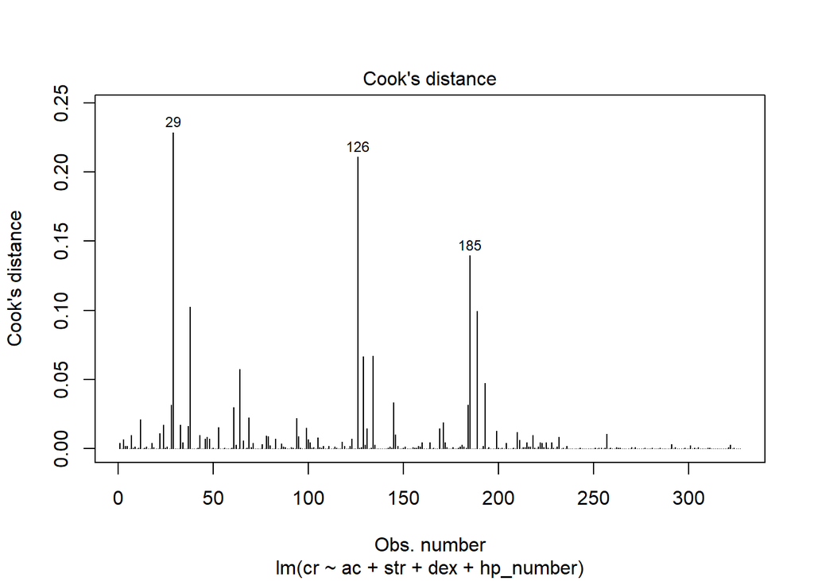

```r
reg_model2 %>%
  plot(which = 4)
```

```r
describe(residuals(reg_model2))
```

```
##    vars   n mean   sd median trimmed  mad  min  max range skew kurtosis   se
## X1    1 327    0 1.23  -0.07   -0.08 0.65 -4.5 5.87 10.37 0.73     3.81 0.07
```

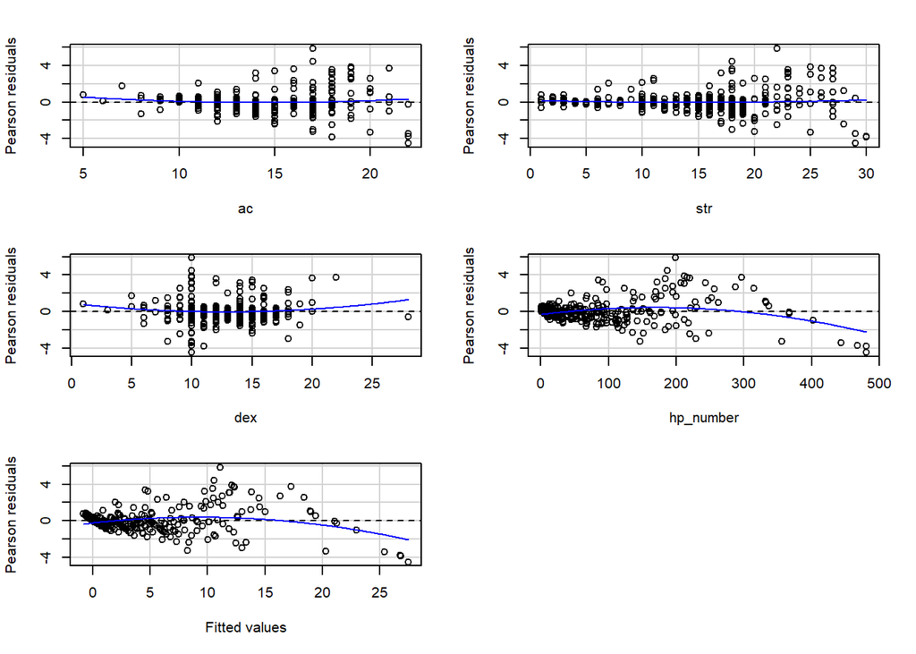

```
##            Test stat Pr(>|Test stat|)
## ac            1.6540          0.09912 .
## str           1.1015          0.27152
## dex           1.7684          0.07794 .
## hp_number    -5.9177        8.373e-09 ***
## Tukey test   -5.4001        6.662e-08 ***
## ---
## Signif. codes:  0 '***' 0.001 '**' 0.01 '*' 0.05 '.' 0.1 ' ' 1
```

```r
reg_model2 %>%
  residualPlots()
```

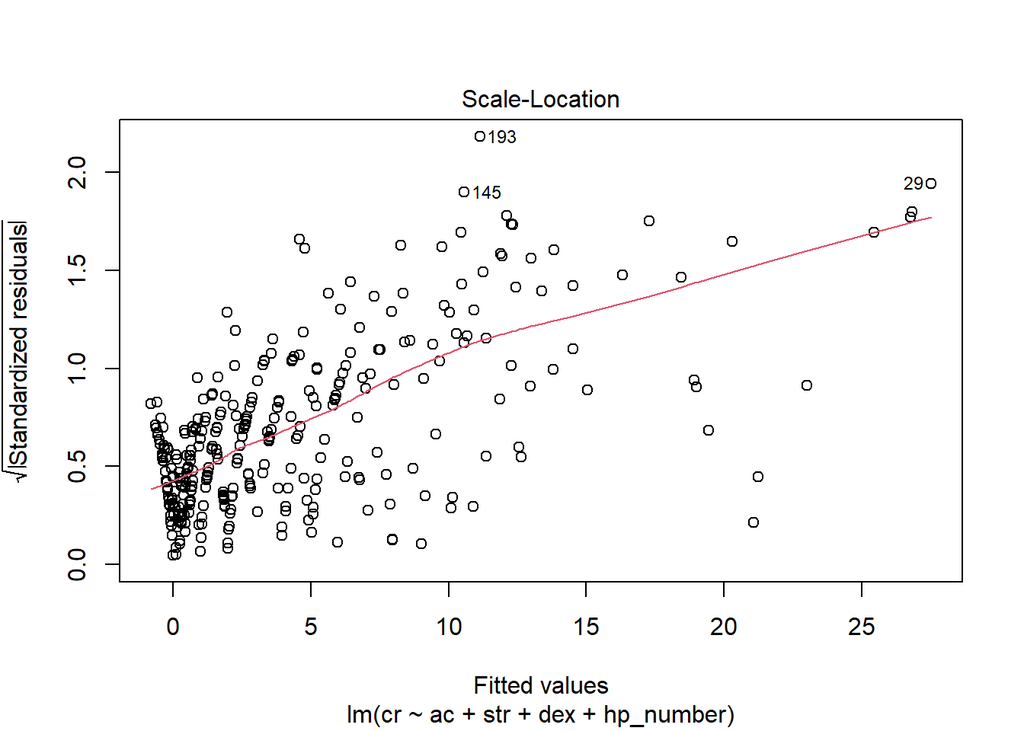

```r
reg_model2 %>%
  plot(which = 3)
```

```r
reg_model2 %>%
  bptest()
```

```
##
##  studentized Breusch-Pagan test
##
## data:  .
## BP = 112.47, df = 4, p-value < 2.2e-16
```

```r
reg_model2 %>%
  vif()
```

```
##        ac       str       dex hp_number
##  2.537391  2.438347  1.313550  3.121635
```

```r
AIC(reg_model2)
```

```
## [1] 1075.986
```

# Results from the second regression

The second model is better, kurtosis is less (Still quite high = 3,81), but on AIC the model rates better, RSE is also lower and adjustedrsquare a bit better. We had to exclude three outliers to achieve this (Tarrasque, Ancient Gold Dragon and Ancient Red dragon) because their hp distored the model. Altough dex and str doesnt show a strong correlation with the cr at all, so we might just well exclude them from the predictors and try out another predictor.

```r
res <- aov(hp_number ~ size, data = Data_modified)

#checking whether there is a difference between HP based on the size category, there might be an interaction going on between these two predictors.

summary(res)
```

```
##              Df  Sum Sq Mean Sq F value Pr(>F)
## size          6 1618583  269764   82.46 <2e-16 ***
## Residuals   320 1046820    3271
## ---
## Signif. codes:  0 '***' 0.001 '**' 0.01 '*' 0.05 '.' 0.1 ' ' 1
```

```r
#its seems like its a certain possibility

reg_model3 <- lm(cr ~ ac + hp_number * size, Data_modified)
summary(reg_model3)
```

```
##
## Call:
## lm(formula = cr ~ ac + hp_number * size, data = Data_modified)
##
## Residuals:
##     Min      1Q  Median      3Q     Max
## -3.4821 -0.4437  0.0352  0.3865  5.4215
##
## Coefficients:
##                                 Estimate Std. Error t value Pr(>|t|)
## (Intercept)                    2.9636854  1.6078833   1.843 0.066245 .
## ac                             0.1258623  0.0298799   4.212 3.31e-05 ***
## hp_number                      0.0380254  0.0040650   9.354  < 2e-16 ***
## sizeHuge                      -6.8824185  1.6342219  -4.211 3.32e-05 ***
## sizeLarge                     -5.3745316  1.5661805  -3.432 0.000681 ***
## sizeMedium                    -5.0983728  1.5625508  -3.263 0.001225 **
## sizeMedium or Small           -5.5815024  1.5839475  -3.524 0.000489 ***
## sizeSmall                     -4.6728560  1.6237062  -2.878 0.004280 **
## sizeTiny                      -4.5471302  1.5797163  -2.878 0.004272 **
## hp_number:sizeHuge             0.0345206  0.0050443   6.843 4.10e-11 ***
## hp_number:sizeLarge            0.0215206  0.0043404   4.958 1.17e-06 ***
## hp_number:sizeMedium           0.0182415  0.0046420   3.930 0.000105 ***
## hp_number:sizeMedium or Small  0.0275400  0.0054842   5.022 8.63e-07 ***
## hp_number:sizeSmall           -0.0036617  0.0351121  -0.104 0.917010
## hp_number:sizeTiny            -0.0001116  0.0270584  -0.004 0.996712
## ---
## Signif. codes:  0 '***' 0.001 '**' 0.01 '*' 0.05 '.' 0.1 ' ' 1
##
## Residual standard error: 1.091 on 312 degrees of freedom
## Multiple R-squared:  0.9615, Adjusted R-squared:  0.9597
## F-statistic: 555.9 on 14 and 312 DF,  p-value: < 2.2e-16
```

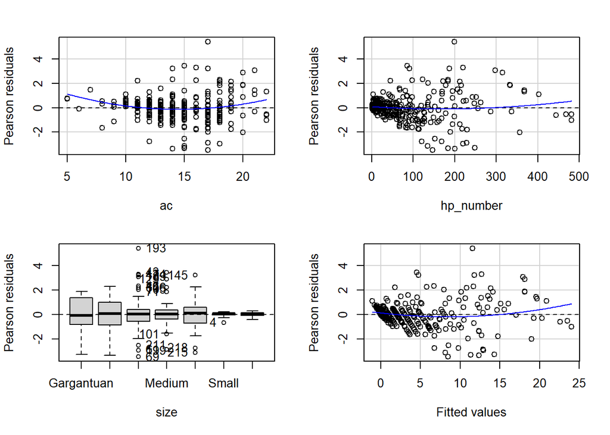

```
##            Test stat Pr(>|Test stat|)
## ac            3.8741        0.0001305 ***
## hp_number     3.7626        0.0002009 ***
## size
## Tukey test    4.9376        7.911e-07 ***
## ---
## Signif. codes:  0 '***' 0.001 '**' 0.01 '*' 0.05 '.' 0.1 ' ' 1
```

```r
reg_model3 %>%
  residualPlots()
```

```r
reg_model3 %>%
  bptest()
```

```
##
##  studentized Breusch-Pagan test
##
## data:  .
## BP = 87.345, df = 14, p-value = 1.201e-12
```

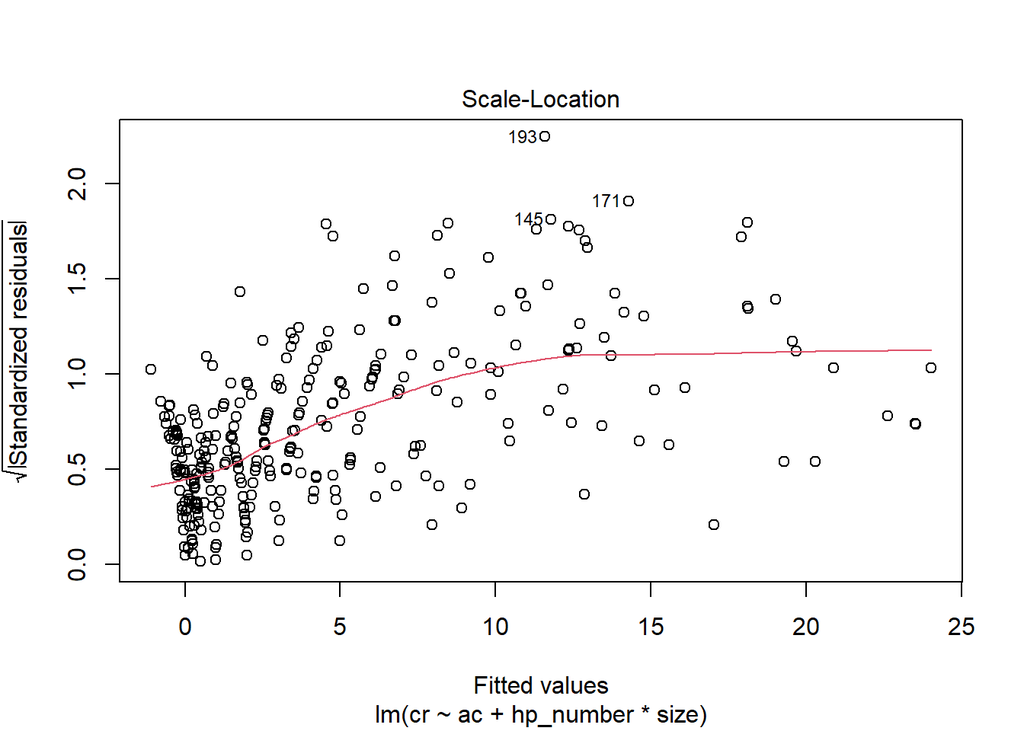

```r
reg_model3 %>%
  plot(which = 3)
```

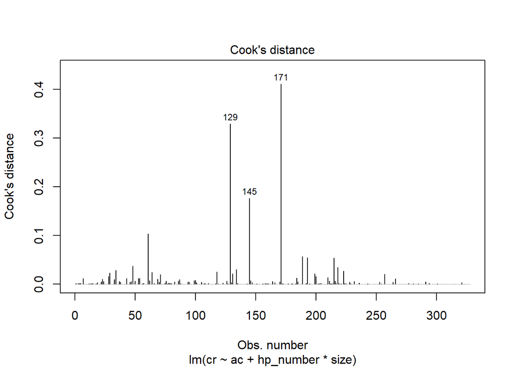

```r
reg_model3 %>%
  plot(which = 4)
```

```r
describe(residuals(reg_model3))
```

```
##    vars   n mean   sd median trimmed  mad   min  max range skew kurtosis   se
## X1    1 327    0 1.07   0.04   -0.02 0.59 -3.48 5.42   8.9 0.31     3.75 0.06
```

```r
reg_model3 %>%
  vif()
```

```
## there are higher-order terms (interactions) in this model
## consider setting type = 'predictor'; see ?vif
```

```
##                      GVIF Df GVIF^(1/(2*Df))
## ac                2.26967  1        1.506542
## hp_number        36.97937  1        6.081066
## size           6919.86123  6        2.089335
## hp_number:size 4437.78281  6        2.013402
```

```r
Data_modified1 <- Data_modified[-c(171, 129, 145), ]
reg_model4 <- lm(cr ~ ac + hp_number * size, Data_modified1)
summary(reg_model4)
```

```
##
## Call:
## lm(formula = cr ~ ac + hp_number * size, data = Data_modified1)
##
## Residuals:
##     Min      1Q  Median      3Q     Max
## -3.4769 -0.4225  0.0205  0.3107  5.4166
##
## Coefficients:
##                                 Estimate Std. Error t value Pr(>|t|)
## (Intercept)                     6.630762   1.810271   3.663 0.000293 ***
## ac                              0.120170   0.028494   4.217 3.25e-05 ***
## hp_number                       0.029664   0.004420   6.711 9.23e-11 ***
## sizeHuge                      -10.485864   1.814951  -5.777 1.85e-08 ***
## sizeLarge                      -8.978383   1.760326  -5.100 5.92e-07 ***
## sizeMedium                     -8.515589   1.756867  -4.847 1.99e-06 ***
## sizeMedium or Small            -8.916221   1.773481  -5.028 8.43e-07 ***
## sizeSmall                      -8.267393   1.804186  -4.582 6.68e-06 ***
## sizeTiny                       -8.147900   1.770361  -4.602 6.11e-06 ***
## hp_number:sizeHuge              0.043052   0.005284   8.148 9.28e-15 ***
## hp_number:sizeLarge             0.030075   0.004694   6.407 5.52e-10 ***
## hp_number:sizeMedium            0.021867   0.005158   4.240 2.96e-05 ***
## hp_number:sizeMedium or Small   0.030428   0.005881   5.174 4.13e-07 ***
## hp_number:sizeSmall             0.004593   0.033351   0.138 0.890560
## hp_number:sizeTiny              0.009025   0.025776   0.350 0.726468
## ---
## Signif. codes:  0 '***' 0.001 '**' 0.01 '*' 0.05 '.' 0.1 ' ' 1
##
## Residual standard error: 1.035 on 309 degrees of freedom
## Multiple R-squared:  0.9641, Adjusted R-squared:  0.9624
## F-statistic: 592.1 on 14 and 309 DF,  p-value: < 2.2e-16
```

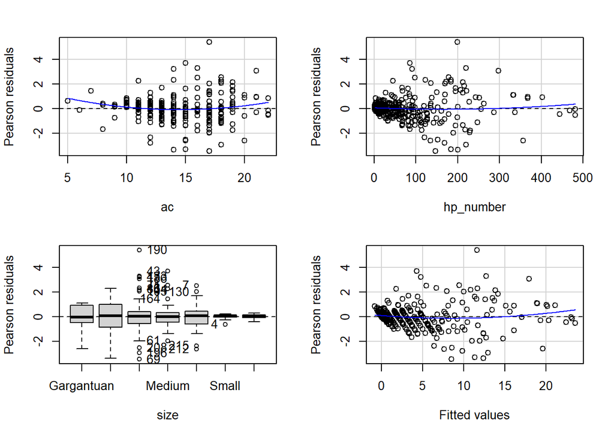

```
##            Test stat Pr(>|Test stat|)
## ac            3.0393        0.0025748 **
## hp_number     2.8864        0.0041726 **
## size
## Tukey test    3.7694        0.0001636 ***
## ---
## Signif. codes:  0 '***' 0.001 '**' 0.01 '*' 0.05 '.' 0.1 ' ' 1
```

```r
reg_model4 %>%
  residualPlots()
```

```r
reg_model4 %>%
  bptest()
```

```
##
##  studentized Breusch-Pagan test
##
## data:  .
## BP = 71.594, df = 14, p-value = 9.916e-10
```